# Statistical Rethinking: Chapter 5

# Multivariate Linear Models

## Spurious association

Does marriage cause divorce?

```r
library(dplyr); library(tidyr); library(rstan); library(skimr); library(ggplot2); library(ggthemes)

# load data
library(rethinking)
data(WaffleDivorce)
d <- WaffleDivorce

# Figure 5.1
ggplot(d) +
  stat_smooth(aes(WaffleHouses/Population, Divorce), method = 'lm', level = .89,
              fullrange = T, color = 'black', alpha = .1, lwd = .3) +
  geom_point(aes(WaffleHouses/Population, Divorce),
             shape = 21, color = 'dodgerblue') +
  geom_text(data = filter(d, Loc %in% c('AL', 'AR', 'GA', 'OK', 'ME', 'NJ', 'SC')),
             aes(x = WaffleHouses/Population + 1.2, y = Divorce, label = Loc), size = 3) +
  scale_x_continuous(limits = c(0, 50)) +
  labs(x = 'Waffle Houses per million', y = 'Divorce Rate')

# standardize predictor
d$MedianAgeMarriage.s <- (d$MedianAgeMarriage - mean(d$MedianAgeMarriage)) / sd(d$MedianAgeMarriage)

# fit the model
m5.1 <- map(
  alist(Divorce ~ dnorm(mu, sigma),
        mu <- a + bA * MedianAgeMarriage.s,
        a ~ dnorm(10, 10),
        bA ~ dnorm(0, 1),
        sigma ~ dunif(0, 10)),
  data = d
)

# results
precis(m5.1)

# compute the percentile interval of the mean
MAM.seq <- seq(from = 3, to = 3.5, length.out = 30)
mu <- link(m5.1, data = data.frame(MedianAgeMarriage.s = MAM.seq))
mu.PI <- apply(mu, 2, PI)

# plot
plot(Divorce ~ MedianAgeMarriage.s, data = d, col = rangi2)
abline(m5.1)
shade(mu.PI, MAM.seq)
```

Same model with Stan:

```stan
data {
  int<lower = 0> N;
  vector[N] Divorce;
  vector[N] MedianAgeMarriage_s;
}

parameters {
  real a;
  real bA;
  real sigma;
}

model {
  // linear model
  vector[N] mu;
  mu = a + bA * MedianAgeMarriage_s;

  // priors
  a ~ normal(10, 10);
  bA ~ normal(0, 1);
  sigma ~ uniform(0, 10);

  // likelihood
  Divorce ~ normal(mu, sigma);
}
```

Now estimate the model:

```r
dat <- list(N = NROW(d),
            Divorce = d$Divorce,
            MedianAgeMarriage_s = d$MedianAgeMarriage.s)

m5.1.stan.fit <- sampling(m5.1.stan,
                          data = dat)
precis(m5.1.stan.fit)

# Plot the model --------------------------------------------------------------
## draw from posterior samples
post <- as.data.frame(m5.1.stan.fit)

## recreate mu and simulate it with new data
f_mu <- function(x) post$a + post$bA * x
a_z_new <- seq(-3, 3)

mu <-
  sapply(a_z_new, f_mu) %>%
  as_tibble() %>%
  rename_all(function(x) a_z_new) %>%
  mutate(Iter = row_number()) %>%
  gather(a_z, divorce, -Iter) %>%
  group_by(a_z) %>%
  mutate(hpdi_l = HDInterval::hdi(divorce, credMass = 0.8)[1],
         hpdi_h = HDInterval::hdi(divorce, credMass = 0.8)[2],
         mu = mean(divorce)) %>%
  ungroup() %>%
  mutate(a_z = as.numeric(a_z))

## plot raw data and model estimate of mu
ggplot() +
  geom_point(data = d,
             aes(x = MedianAgeMarriage.s, y = Divorce),
             shape = 1,
             color = "blue") +
  geom_ribbon(data = mu,
              aes(x = a_z, ymin = hpdi_l, ymax = hpdi_h), alpha = 0.1) +
  geom_line(data = mu, aes(x = a_z, y = mu))
```

```r
# standardize predictor
d$Marriage.s <- (d$Marriage - mean(d$Marriage)) / sd(d$Marriage)

# fit the model
m5.2 <- map(
  alist(Divorce ~ dnorm(mu, sigma),
        mu <- a + bR * Marriage.s,
        a ~ dnorm(10, 10),
        bR ~ dnorm(0, 1),
        sigma ~ dunif(0, 10)),
  data = d
)

# results
precis(m5.2)

# compute the percentile interval of the mean
MAM.seq <- seq(from = 3, to = 3.5, length.out = 30)
mu <- link(m5.2, data = data.frame(Marriage.s = MAM.seq))
mu.PI <- apply(mu, 2, PI)

# plot
plot(Divorce ~ Marriage.s, data = d, col = rangi2)
abline(m5.2)
shade(mu.PI, MAM.seq)
```

Now the Stan model with `Marrage_s`:

```stan
data {
  int<lower = 0> N;
  vector[N] Divorce;
  vector[N] Marriage_s;
}

parameters {
  real a;
  real bR;
  real sigma;
}

model {
  // linear model
  vector[N] mu;
  mu = a + bR * Marriage_s;

  // priors
  a ~ normal(10, 10);
  bR ~ normal(0, 1);
  sigma ~ uniform(0, 10);

  // likelihood
  Divorce ~ normal(mu, sigma);
}
```

Now estimate the Stan model:

```r
dat <- list(N = NROW(d),
            Divorce = d$Divorce,
            Marriage_s = d$Marriage.s)

m5.2.stan.fit <- sampling(m5.2.stan,
                          data = dat)
precis(m5.2.stan.fit)

# Plot the model --------------------------------------------------------------
## draw from posterior samples
post <- as.data.frame(m5.2.stan.fit)

## recreate mu and simulate it with new data
f_mu <- function(x) post$a + post$bR * x
a_z_new <- seq(-3, 3)

mu <-
  sapply(a_z_new, f_mu) %>%
  as_tibble() %>%
  rename_all(function(x) a_z_new) %>%
  mutate(Iter = row_number()) %>%
  gather(a_z, divorce, -Iter) %>%
  group_by(a_z) %>%
  mutate(hpdi_l = HDInterval::hdi(divorce, credMass = 0.8)[1],
         hpdi_h = HDInterval::hdi(divorce, credMass = 0.8)[2],
         mu = mean(divorce)) %>%
  ungroup() %>%
  mutate(a_z = as.numeric(a_z))

## plot raw data and model estimate of mu
ggplot() +
  geom_point(data = d,
             aes(x = Marriage.s, y = Divorce),
             shape = 1,
             color = "blue") +
  geom_ribbon(data = mu,
              aes(x = a_z, ymin = hpdi_l, ymax = hpdi_h), alpha = 0.1) +
  geom_line(data = mu, aes(x = a_z, y = mu))
```

Now let’s add both variables:

```r
# fit the model
m5.3 <- map(
  alist(Divorce ~ dnorm(mu, sigma),
        mu <- a + bA * MedianAgeMarriage.s + bR * Marriage.s,
        a ~ dnorm(10, 10),
        bA ~ dnorm(0, 1),
        bR ~ dnorm(0, 1),
        sigma ~ dunif(0, 10)),
  data = d
)

# results
precis(m5.3)

plot(precis(m5.3))

# compute the percentile interval of the mean
MAM.seq <- seq(from = 3, to = 3.5, length.out = 30)
mu <- link(m5.2, data = data.frame(Marriage.s = MAM.seq))
mu.PI <- apply(mu, 2, PI)

# plot
plot(Divorce ~ Marriage.s, data = d, col = rangi2)
abline(m5.2)
shade(mu.PI, MAM.seq)
```

Both variables in the Stan model:

```stan
data {
  int<lower = 0> N;
  vector[N] Divorce;
  vector[N] MedianAgeMarriage_s;
  vector[N] Marriage_s;
}

parameters {
  real a;
  real bA;
  real bR;
  real sigma;
}

model {
  // linear model
  vector[N] mu;
  mu = a + bA * MedianAgeMarriage_s + bR * Marriage_s;

  // priors
  a ~ normal(10, 10);
  bA ~ normal(0, 1);
  bR ~ normal(0, 1);
  sigma ~ uniform(0, 10);

  // likelihood
  Divorce ~ normal(mu, sigma);
}
```

Now estimate the Stan model with both parameters:

```r
dat <- list(N = NROW(d),
            Divorce = d$Divorce,
            Marriage_s = d$Marriage.s,
            MedianAgeMarriage_s = d$MedianAgeMarriage.s)

m5.3.stan.fit <- sampling(m5.3.stan,
                          data = dat)
precis(m5.3.stan.fit)
```

### Plotting to intrepret linear regression

We will cover three techniques:

1. Predictor residual plots: These show the outcome against residual predictor values
2. Counterfactual plots: These show implied predictions for imaginary experiments in which the different variables can be changed independently of on another
3. Posterior prediction plots: These show model-based predictions against raw data, or otherwise display the error in prediction

#### Predictor residual plots

```r
m5.4 <- map(
  alist(Marriage.s ~ dnorm(mu, sigma),
        mu <- a + b * MedianAgeMarriage.s,
        a ~ dnorm(0, 10),
        b ~ dnorm(0, 1),
        sigma ~ dunif(0, 10)),
  data = d
)

# now calculate residuals by subtracting observed marriage rate in each state
# from the predicted rate

# compute expected value at MAP for each state
mu <- coef(m5.4)["a"] + coef(m5.4)["b"] * d$MedianAgeMarriage.s

# compute residual for each state
m.resid <- d$Marriage.s - mu

# plot
plot(Marriage.s ~ MedianAgeMarriage.s, d, col = rangi2)
abline(m5.4)
## loop over states
for (i in 1:length(m.resid)) {
  x <- d$MedianAgeMarriage.s[i] # x location of line segment
  y <- d$Marriage.s[i] # observed endpoint of line segment

  # draw line segment
  lines(c(x, x), c(mu[i], y), lwd = 0.5, col = col.alpha("black", 0.7))
}
```

Stan model:

```stan
data {
  int<lower = 0> N;
  vector[N] Marriage_s;
  vector[N] MedianAgeMarriage_s;
}

parameters {
  real a;
  real b;
  real sigma;
}

model {
  // linear model
  vector[N] mu;
  mu = a + b * MedianAgeMarriage_s;

  // prior
  a ~ normal(0, 10);
  b ~ normal(0, 1);
  sigma ~ uniform(0, 10);

  // likelihood
  Marriage_s ~ normal(mu, sigma);
}
```

#### Counterfactual plots

```r
# prepare new counterfactual data
A.avg <- mean(d$MedianAgeMarriage.s)
R.seq <- seq(from = -3, to = 3, length.out = 30)
pred.data <- data.frame(Marriage.s = R.seq,
                        MedianAgeMarriage.s = A.avg)

# compute counterfactual mean divorce (mu)
mu <- link(m5.3, data = pred.data)
mu.mean <- apply(mu, 2, mean)
mu.PI <- apply(mu, 2, PI)

# simulate counterfactual divorce outcomes
R.sim <- sim(m5.3, data = pred.data, n = 10000)
R.PI <- apply(R.sim, 2, PI)

# display predictions, hiding raw data with type = "n"
plot(Divorce ~ Marriage.s, data = d, type = "n")
mtext("MedianAgeMarriage.s = 0")
lines(R.seq, mu.mean)
shade(mu.PI, R.seq)
shade(R.PI, R.seq)

# From Stan model -------------------------------------------------------------
## get draws for parameters
post <- as.matrix(m5.3.stan.fit)

## setup new data
nd <-
  expand.grid(median_age_s = seq(-3, 3),
              marriage_s = seq(-3, 3)) %>%
  as.matrix()

## estimate mu
mu <- post[ , 1] + post[ , 2:3] %*% t(nd)

## get stats on mu
avg <- colMeans(mu)
hdi <- apply(mu, 2, HDInterval::hdi)

## simulate divorce rate
iter <- 1e4
y_hat <- matrix(nrow = iter, ncol = NROW(nd))
for(i in 1:NROW(nd)) y_hat[,i] <- rnorm(iter, post[,1] + post[,2:3] %*% as.matrix(nd[i,]), post[,4])

## get stats on sim
y_hat_avg <- colMeans(y_hat)
y_hat_hdi <- apply(y_hat, 2, HDInterval::hdi)
nd <-
  as_tibble(nd) %>%
  bind_cols(avg = avg,
            mu_hdi_l = hdi[1,],
            mu_hdi_h = hdi[2,],
            y_hdi_l = y_hat_hdi[1,],
            y_hdi_h = y_hat_hdi[2,])

ggplot(nd, aes(x = median_age_s, y = avg, group = marriage_s)) +
  geom_line(data = nd,
            color = 'gray90') +
  geom_ribbon(data = nd %>% filter(marriage_s == 0),
              aes(x = median_age_s, ymin = mu_hdi_l, ymax = mu_hdi_h), alpha = .1) +
  geom_ribbon(data = nd %>% filter(marriage_s == 0),
              aes(x = median_age_s, ymin = y_hdi_l, ymax = y_hdi_h), alpha = .1) +
  geom_line(data = nd %>% filter(marriage_s == 0),
            aes(x = median_age_s, y = avg)) +
  geom_text(data = nd %>% filter(median_age_s == min(median_age_s)),
            aes(label = marriage_s, x = median_age_s - 0.1, y = avg), size = 2) +
  geom_text(data = nd %>% filter(median_age_s == max(median_age_s)),
            aes(label = marriage_s, x = median_age_s + 0.1, y = avg), size = 2) +
  labs(x = 'Standardized Median Age of Marriage', y = 'Divorce rate')
```

#### Posterior prediction plots

Useful for checking the model fit and where the model fails.

```r
# call link without specifying new data so it uses orignial data
mu <- link(m5.3)

# summarize samples across cases
mu.mean <- apply(mu, 2, mean)
mu.PI <- apply(mu, 2, PI)

# simulate observations
# again no new data, so it uses original data
divorce.sim <- sim(m5.3, n = 10000)
divorce.PI <- apply(divorce.sim, 2, PI)

# plot predicted values against observed
plot(mu.mean ~ d$Divorce, col = rangi2, ylim = range(mu.PI),
     xlab = "Observed Divorce", ylab = "Predicted Divorce")
abline(a = 0, b = 1, lty = 2)
for (i in 1:nrow(d)) {
  lines(rep(d$Divorce[i], 2), c(mu.PI[1, i], mu.PI[2, i]), col = rangi2)
}
identify(x = d$Divorce, y = mu.mean, labels = d$Loc, cex = 0.8)

# From Stan model -------------------------------------------------------------
## estimate mu
mu <- post[ , 1] + post[ , 2:3] %*% t(d[ , 14:15])

## get stats on mu
avg <- colMeans(mu)
hdi <- apply(mu, 2, HDInterval::hdi)

## simulate divorce rate
iter <- 1e4
y_hat <- matrix(nrow = iter, ncol = NROW(d[ , 14:15]))
for(i in 1:NROW(d[ , 14:15])) y_hat[ , i] <- rnorm(iter, post[ , 1] + post[ , 2:3] %*% t(d[i, 14:15]), post[ , 4])

## get stats on sim
y_hat_avg <- colMeans(y_hat)
y_hat_hdi <- apply(y_hat, 2, HDInterval::hdi)
d <- d %>% mutate(mu = avg,
                  mu_hdi_l = hdi[1,],
                  mu_hdi_h = hdi[2,],
                  y_hdi_l = y_hat_hdi[1,],
                  y_hdi_h = y_hat_hdi[2,])

ggplot() +
  geom_abline(intercept = 0, slope = 1,
              linetype = 'dashed', color = 'gray70') +
  geom_segment(data = d,
               aes(x = Divorce, xend = Divorce,
                   y = mu_hdi_l, yend = mu_hdi_h),
               color = 'dodgerblue') +
  geom_point(data = d,
             aes(Divorce, mu),
             shape = 1, color = 'dodgerblue', fill = 'white') +
  labs(x = "Observed divorce rate", y = 'Estimated average divorce rate',
       subtitle = 'Observed versus\nestimated for each state')
```

Residual plot:

```r
# compute residuals
divorce.resid <- d$Divorce - mu.mean

# get ordering by divorce rate
o <- order(divorce.resid)

# plot
dotchart(divorce.resid[o], labels = d$Loc[o], xlim = c(-6, 5), cex = 0.6)
abline(v = 0, col = col.alpha("black", 0.2))
for (i in 1:nrow(d)) {
  j <- o[i] # which state order
  lines(d$Divorce[j] - c(mu.PI[1, j], mu.PI[2, j]), rep(i, 2))
  points(d$Divorce[j] - c(divorce.PI[1, j], divorce.PI[2, j]), rep(i, 2),
         pch = 3, cex = 0.6, col = "gray")
}
```

## Masked Relationship

```r
library(rethinking)
data(milk)
d <- milk
str(d)
```

Consider a bivariate regression between kilocarories and neocotrex percent:

```r
m5.5 <- map(
  alist(kcal.per.g ~ dnorm(mu, sigma),
        mu <- a + bn * neocortex.perc,
        a ~ dnorm(0, 100),
        bn ~ dnorm(0, 1),
        sigma ~ dunif(0, 1)),
  data = d
)
```

```r
d$neocortex.perc

# drop missing values
dcc <- d[complete.cases(d), ]

# re-estimate the model
m5.5 <- map(
  alist(kcal.per.g ~ dnorm(mu, sigma),
        mu <- a + bn * neocortex.perc,
        a ~ dnorm(0, 100),
        bn ~ dnorm(0, 1),
        sigma ~ dunif(0, 1)),
  data = dcc
)

# results
precis(m5.5, digits = 3)
```

Plot the predicted mean and 89% interval for the mean:

```r
np.seq <- 0:100
pred.data <- data.frame(neocortex.perc = np.seq)

mu <- link(m5.5, data = pred.data, n = 10000)
mu.mean <- apply(mu, 2, mean)
mu.PI <- apply(mu, 2, PI)

plot(kcal.per.g ~ neocortex.perc, data = dcc, col = rangi2)
lines(np.seq, mu.mean)
lines(np.seq, mu.PI[1, ], lty = 2)
lines(np.seq, mu.PI[2, ], lty = 2)
```

Now let’s add in the natural log of `mass`:

```r
dcc$log.mass = log(dcc$mass)

# fit the model
m5.6 <- map(
  alist(kcal.per.g ~ dnorm(mu, sigma),
        mu <- a + bm * log.mass,
        a ~ dnorm(0, 100),
        bm ~ dnorm(0, 1),
        sigma ~ dunif(0, 1)),
  data = dcc
)

precis(m5.6)

# plot
mp.seq <- 0:100
pred.data <- data.frame(log.mass = mp.seq)

mu <- link(m5.6, data = pred.data, n = 10000)
mu.mean <- apply(mu, 2, mean)
mu.PI <- apply(mu, 2, PI)

plot(kcal.per.g ~ log.mass, data = dcc, col = rangi2)
lines(mp.seq, mu.mean)
lines(mp.seq, mu.PI[1, ], lty = 2)
lines(mp.seq, mu.PI[2, ], lty = 2)
```

Now both variables together:

```r
# fit the model
m5.7 <- map(
  alist(kcal.per.g ~ dnorm(mu, sigma),
        mu <- a + bn * neocortex.perc + bm * log.mass,
        a ~ dnorm(0, 100),
        bn ~ dnorm(0, 1),
        bm ~ dnorm(0, 1),
        sigma ~ dunif(0, 1)),
  data = dcc
)

precis(m5.7)

# plot
mean.log.mass <- mean(log(dcc$mass))
np.seq <- 0:100
pred.data <- data.frame(neocortex.perc = np.seq,
                        log.mass = mean.log.mass)

mu <- link(m5.7, data = pred.data, n = 10000)
mu.mean <- apply(mu, 2, mean)
mu.PI <- apply(mu, 2, PI)

mp.seq <- 0:100
pred.data <- data.frame(log.mass = mp.seq)

plot(kcal.per.g ~ neocortex.perc, data = dcc, col = rangi2)
lines(mp.seq, mu.mean)
lines(mp.seq, mu.PI[1, ], lty = 2)
lines(mp.seq, mu.PI[2, ], lty = 2)
```

## When adding variables hurts

### Multicollinearity

This is a simulation predicting an individual’s height using the length of his or her legs as predictor variables.

```r
N <- 100 # number of individuals
height <- rnorm(N, 10, 2) # sim total height of each
leg_prop <- runif(N, 0.4, 0.5)
leg_left <- leg_prop * height + rnorm(N, 0, 0.02) # sim left leg as proportion + error
leg_right <- leg_prop * height + rnorm(N, 0, 0.02) # sim right leg as proportion + error
d <- data.frame(height, leg_left, leg_right) # combine into data frame

# fit a model
m5.8 <- map(
  alist(height ~ dnorm(mu, sigma),
        mu <- a + bl * leg_left + br * leg_right,
        a ~ dnorm(10, 100),
        bl ~ dnorm(2, 10),
        br ~ dnorm(2, 10),
        sigma ~ dunif(0, 10)),
  data = d
)

precis(m5.8)

plot(precis(m5.8))

post <- extract.samples(m5.8)
plot(bl ~ br, post, col = col.alpha(rangi2, 0.1), pch = 16)


# plotting the posterior sum
sum_blbr <- post$bl + post$br
dens(sum_blbr, col = rangi2, lwd = 2, xlab = "Sum of bl and br")
```

Fitting a model with only one of these predictors will produce almost the same posterior mean:

```r
# fit a model
m5.9 <- map(
  alist(height ~ dnorm(mu, sigma),
        mu <- a + bl * leg_left,
        a ~ dnorm(10, 100),
        bl ~ dnorm(2, 10),
        sigma ~ dunif(0, 10)),
  data = d
)

precis(m5.9)
```

Back to the milk data

```r
library(rethinking)
data(milk)
d <- milk

# k.cal.per.g regressed on perc.fat
m5.10 <- map(
  alist(kcal.per.g ~ dnorm(mu, sigma),
        mu <- a + bf * perc.fat,
        a ~ dnorm(0.6, 10),
        bf ~ dnorm(0, 1),
        sigma ~ dunif(0, 10)),
  data = d
)

# kcal.per.g regressed on perc.lactose
m5.11 <- map(
  alist(kcal.per.g ~ dnorm(mu, sigma),
        mu <- a + bl * perc.lactose,
        a ~ dnorm(0.6, 10),
        bl ~ dnorm(0, 1),
        sigma ~ dunif(0, 10)),
  data = d
)

precis(m5.10, digits = 3)
precis(m5.11, digits = 3)

# now including both
m5.12 <- map(
  alist(kcal.per.g ~ dnorm(mu, sigma),
        mu <- a + bf * perc.fat + bl * perc.lactose,
        a ~ dnorm(0.6, 10),
        bf ~ dnorm(0, 1),
        bl ~ dnorm(0, 1),
        sigma ~ dunif(0, 10)),
  data = d
)

precis(m5.12, digits = 3)

pairs(~ kcal.per.g + perc.fat + perc.lactose, data = d, col = rangi2)

cor(d$perc.fat, d$perc.lactose)
```

### Post-treatment bias

SUppose we want to know the difference in growth under different antifungal soil treatments, because fungus on the plants tends to reduce their growth.

```r
# number of plants
N <- 100

# simulate initial heights
h0 <- rnorm(N, 10, 2)

# assign treatments and simulate fungus and growth
treatment <- rep(0:1, each = N / 2)
fungus <- rbinom(N, size = 1, prob = 0.5 - treatment * 0.4)
h1 <- h0 + rnorm(N, 5 - 3 * fungus)

# compose a clean data frame
d <- data.frame(h0 = h0, h1 = h1, treatment = treatment, fungus = fungus)

# fit model
m5.13 <- map(
  alist(h1 ~ dnorm(mu, sigma),
        mu <- a + bh * h0 + bt * treatment + bf * fungus,
        a ~ dnorm(0, 100),
        c(bh, bt, bf) ~ dnorm(0, 10),
        sigma ~ dunif(0, 10)),
  data = d
)

precis(m5.13)
```

We know that the treament is important so what is happening is that fungus is mostly a consequence of treatment. Thus, this model is really asking, “once we already know whether or not a plant developed fungus, does the soil treatment matter?” What we really want to know is the impact of treatment on growth:

```r
# fit model
m5.14 <- map(
  alist(h1 ~ dnorm(mu, sigma),
        mu <- a + bh * h0 + bt * treatment,
        a ~ dnorm(0, 100),
        c(bh, bt) ~ dnorm(0, 10),
        sigma ~ dunif(0, 10)),
  data = d
)

precis(m5.14)
```

## Categorical variables

### Binary categories

```r
data(Howell1)
d <- Howell1
str(d)

# fit model
m5.15 <- map(
  alist(height ~ dnorm(mu, sigma),
        mu <- a + bm * male,
        a ~ dnorm(178, 100),
        bm ~ dnorm(0, 10),
        sigma ~ dunif(0, 50)),
  data = d
)

m5.15.stan.rt <- map2stan(m5.15)
stancode(m5.15.stan.rt)
precis(m5.15)

# posterior of a and bm
post <- extract.samples(m5.15)
mu.male <- post$a + post$bm
PI(mu.male)
```

```stan
data {
  int<lower = 0> N;
  vector[N] height;
  vector[N] male;
}

parameters {
  real a;
  real bm;
  real sigma;
}

model {
  vector[N] mu;
  mu = a + bm * male;

  a ~ normal(178, 100);
  bm ~ normal(0, 10);
  sigma ~ uniform(0, 50);

  height ~ normal(mu, sigma);
}
```

```r
dat <- list(N = NROW(d),
            height = d$height,
            male = d$male)

m5.15.stan.fit <- sampling(m5.15.stan,
                           data = dat)
precis(m5.15.stan.fit)
```

#### Many categories

[figure not shown]

```stan
data {
  int n;
  vector[n] kcal_per_g;
  vector[n] clade_NWM;
  vector[n] clade_OWM;
  vector[n] clade_s;
}

parameters {
  real a;
  real b_NWM;
  real b_OWM;
  real b_s;
  real sigma;
}

model {
  // linear model
  vector[n] mu;
  mu = a + b_NWM * clade_NWM + b_OWM * clade_OWM + b_s * clade_s;

  // priors
  a ~ normal(0.6, 10);
  b_NWM ~ normal(0, 1);
  b_OWM ~ normal(0, 1);
  b_s ~ normal(0, 1);
  sigma ~ uniform(0, 10);

  // likelihood
  kcal_per_g ~ normal(mu, sigma);
}
```

Or the model with index variables:

```stan
data {
  int n;
  int n_clade;
  real kcal_per_g[n];
  int clade[n];
}

parameters {
  vector[n_clade] a;
  real sigma;
}

model {
  //linear model
  vector[n] mu;
  for (i in 1:n) {
    mu[i] = a[clade[i]];
  }

  // priors
  a ~ normal(0.6, 10);
  sigma ~ uniform(0, 10);

  // likelihood
  kcal_per_g ~ normal(mu, sigma);
}

generated quantities {
  vector[n] mu;
  for (i in 1:n) {
    mu[i] = a[clade[i]];
  }
}
```

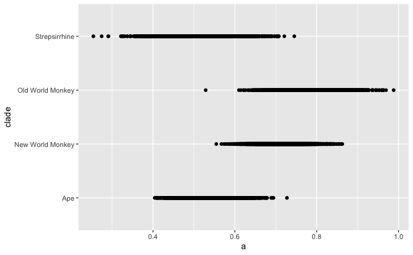

To get posterior distributions of the average milk energy in each category, use samples:

```r
# sample posterior
post <- extract.samples(m5.16)

# compute averages for each category
mu.ape <- post$a
mu.NWM <- post$a + post$b.NWM
mu.OWM <- post$a + post$b.OWM
mu.S <- post$a + post$b.S

# summarize using precis
precis(data.frame(mu.ape, mu.NWM, mu.OWM, mu.S))
```

What if we wanted to know the difference between the two monkey groups? We just subtract the estimated means to get a difference:

```r
diff.NWM.OWM <- mu.NWM - mu.OWM
quantile(diff.NWM.OWM, probs = c(0.025, 0.5, 0.975))
```